# Ford GoBike Ride Frequencies per User Type and Gender

## by Wafula Abdalah Hassani

## Investigation Overview

In this investigation, I wanted assess how Rides frequencies vary by categorical features. The main focus was put on user type, time of the day, day of the week and member gender.

## Dataset Overview

The dataset consists of information regarding 183,412 individual rides made in Bike sharing system covering the San Francisco Bay area. The dataset consists of features such as Customer type, gender, ride durations and other additional variables.

## Rides Frequency per day

More trips were made on Weekdays (Monday - Friday) as compared to weekends (Saturday - Sunday) and a high volume of trips were recorded on Thursday.

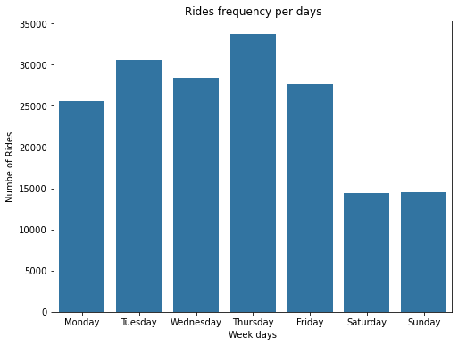

## Rides Frequency per hour

High peaks were recorded in the morning hours i.e. 8AM and 9AM and evening hours i.e. 4PM - 6PM. This showed that more trips were made before and after office/working hours. A substanstial decline in trips recorded was observed in hours after 6PM

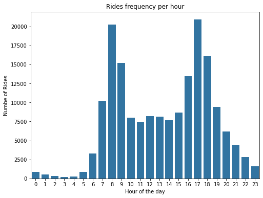

## Rides Frequency per User Type

Majority of the users are Subscribers accounting to over 90% with a substantial difference to Customers of ~9%

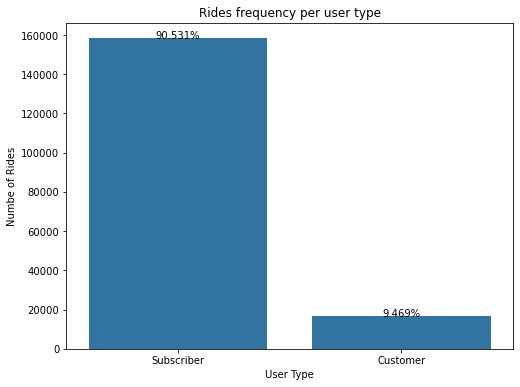

## Rides Frequency per member gender

Majority of the users are Male with over 74.5% as compared to Female with ~23% and 2% of other gender

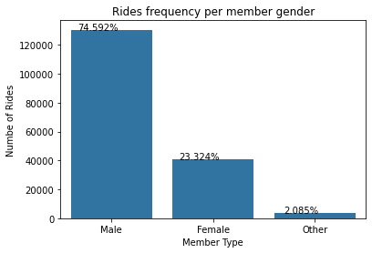